# w5b: Causal Representation

[Nao Mimoto](https://nmimoto.github.io/) - [Dept. of Statistics](http://www.uakron.edu/stat/) : [The University of Akron](http://www.uakron.edu)

[Class Web Page](https://nmimoto.github.io/477/)

## 1. Characteristic Polinomal

### Alternative Notation for AR(1)

We began with writing AR(1) as
$$X_t = \phi X_{t-1} + \epsilon_t,$$

We could also write AR(1) as
$$X_t - \phi X_{t-1} = \epsilon_t,$$
and using the **backward operator**, write
$$\underbrace{ (1 - \phi B) }_{\Phi(B)} X_t = \epsilon_t.$$

$\Phi(z)$ is called **characteristic polynomial** of AR(1).

Backward operator makes it go back a day:
$$B X_t = X_{t-1}.$$

### AR(p) process

Autoregressive process of order $p$ is
$$X_t - \phi_1 X_{t-1} - \phi_2 X_{t-2} - \cdots - \phi_p X_{t-p}
\hspace3mm = \hspace3mm \epsilon_t, \\ \\
\mbox{ where } \epsilon_t \sim WN(0,\sigma^2)$$
and $\phi_1, \ldots, \phi_p$ is real valued constant.

Alternative notation using characteristic polynomial is,
$$\underbrace{ (1 - \phi_1 B - \phi_2 B^2 - \cdots - \phi_p B^p) }_{\Phi(B) }
\, X_t \hspace3mm = \hspace3mm \epsilon_t. \\\\\\
\Phi(B) \hspace3mm X_t \hspace3mm = \hspace3mm \epsilon_t.$$

## 2. Causal Representation

### For AR(1)

If AR(1) representation is
$$X_t \hspace3mm = \hspace3mm \phi X_{t-1} + \epsilon_t,$$
then I can write the same thing for yesterday,
$$X_{t-1} \hspace3mm = \hspace3mm \phi X_{t-2} + \epsilon_{t-1}$$

Now combining the two, I can write
$$\begin{align}
X_t &\hspace3mm = \hspace3mm \phi \, X_{t-1} + \epsilon_t \\ \\
&\hspace3mm = \hspace3mm \phi \big\{\phi X_{t-2} + \epsilon_{t-1} \big\} + \epsilon_t \\ \\
&\hspace3mm = \hspace3mm \phi^2 X_{t-2} + \hspace3mm \phi \epsilon_{t-1} + \epsilon_t
\end{align}$$

Do it again, this time for $X_{t-2}$ and we get
$$\begin{align}
X_t
&\hspace3mm = \hspace3mm \phi^2 X_{t-2} \hspace3mm + \hspace3mm \phi \, \epsilon_{t-1} + \epsilon_t \\ \\
&\hspace3mm = \hspace3mm \phi^2 \big(\phi X_{t-3} + \epsilon_{t-2} \big) \hspace3mm + \hspace3mm \phi \, \epsilon_{t-1} + \epsilon_t \\ \\
&\hspace3mm = \hspace3mm \phi^3 X_{t-3} \hspace3mm + \hspace3mm \phi^2
\, \epsilon_{t-2} + \phi \epsilon_{t-1} + \epsilon_t
\end{align}$$

We can keep doing this, and get
$$X_t
\hspace3mm = \hspace3mm \phi^k X_{t-k}
\hspace3mm + \hspace3mm\phi^{k-1} e_{t-(k-1)}
\hspace3mm + \hspace3mm \cdots \hspace3mm + \hspace3mm \phi \, \epsilon_{t-1}
\hspace3mm + \hspace3mm \epsilon_t$$

If $|\phi|<1$, then letting $k \to \infty$ will yield
$$X_t \hspace3mm = \hspace3mm \epsilon_t + \phi \epsilon_{t-1} + \phi^2 \epsilon_{t-2} + \cdots
\hspace3mm = \hspace3mm \sum_{i=0}^\infty \phi^{i} \, \epsilon_{t-i}$$

So here’s **causal representation** for AR(1) process
$$X_t
\hspace3mm = \hspace3mm \sum_{i=0}^\infty \phi^{i} \, \epsilon_{t-i}
\hspace3mm = \hspace3mm \epsilon_t + \phi \, \epsilon_{t-1} + \phi^2 \, \epsilon_{t-2} + \cdots$$

This is called **causal representation** because we can write $Y_t$ as infinite sum of **past** errors (innovations).

### Get Mean of AR(1) using Causal Representation

Now it is easy to see that mean of AR(1)
$$E(X_t) \hspace3mm = \hspace3mm \sum_{i=0}^\infty \phi^{i} \, E( \epsilon_{t-i} )
\hspace3mm = \hspace3mm 0$$

Recall $\epsilon_t$ are White Noise with mean 0 and variance $\sigma$.

Or often, we assume
$$\epsilon_t \sim N(0,\sigma^2)$$

### Get Var with Causal Representation

So if you write AR(1) in causal way,
$$X_t = \sum_{i=0}^\infty \phi^{i} \, \epsilon_{t-i},$$

Then we can calculate variance as
$$\begin{align}
\mbox{Var}(X_t) \hspace3mm = \hspace3mm
\mbox{Var } \Big[ \sum_{i=0}^\infty \phi^i \, \epsilon_{t-i}\Big]
\hspace3mm = \hspace3mm \sum_{i=0}^\infty \mbox{Var}\big[\phi^i \, \epsilon_{t-i}\big]
\hspace3mm = \hspace3mm \sum_{i=0}^\infty \phi^{2i} \mbox{Var}(\epsilon_{t-i})
\hspace3mm = \hspace3mm \sigma^2 \sum_{i=0}^\infty \phi^{2i}
\end{align}$$
This does not converge unless $|\phi|<1$.

When it does converge, the variance is $\sigma^2/(1-\phi^2)$.

### When Char. Poly. can be written with Causal Rep?

Recall yet another way to write AR(1),
$$(1-\phi B) \, X_t \hspace3mm = \hspace3mm \epsilon_t.$$

This means that we can write
$$X_t \hspace3mm = \hspace3mm \frac{1}{(1-\phi \, B)} \, \epsilon_t.$$

Compare this with Causal representation
$$X_t \hspace3mm = \hspace3mm \epsilon_t + \phi \, \epsilon_{t-1} + \phi^2 \, \epsilon_{t-2} + \cdots
\hspace3mm = \hspace3mm 1+\phi B+ \phi^2 B^2 + \cdots \, \epsilon_t$$

So we have the equivalence on the right hand side,
$$\frac{1}{(1-\phi B)}
\hspace3mm = \hspace3mm 1 + \phi B + \phi^2 B^2 + \phi^3 B^3 + \cdots$$

This is exactly same as the geometric series,
$$\frac{1}{1-x} \hspace3mm = \hspace3mm 1 + x + x^2 + x^3 + \cdots$$

Note that the condition for the geometiric series is
$$|x| < 1 \hspace10mm \mbox{ or } \hspace10mm |\phi| <1$$
Which is same as the **causal (stationary) condition**.

### Writing AR(p) in Causal Rep.

Using the characteristic polynomial,
$$\Phi(B) \, X_t \hspace3mm = \hspace3mm \epsilon_t \\ \\
X_t \hspace3mm = \hspace3mm \frac{1}{\Phi(B)} \,\, \epsilon_t$$
That means we must be able to write polynomial as
$$\frac{1}{\big(1 - \phi_1 B - \phi_2 B^2 - \cdots - \phi_p B^p\big) }
\hspace3mm = \hspace3mm
\big(
\psi_0 + \psi_1 B + \psi_2 B^2 + \psi_3 B^3 + \cdots
\big)$$
When can we do this?

### Causal Condition for AR(p)

From operator theory, we know that if
$$\mbox{ (complex) root of } \Phi(z) \mbox{ is outside of the unit circle, } \\$$
we can expand the inverse of $\Phi(z)$ as
$$\frac{1}{\Phi(z)} \hspace3mm = \hspace3mm \psi_0 + \psi_1 z + \psi_2 z^2 + \psi_3 z^3 + \cdots$$

This is the condition that allows us to write AR(p) in causal representation.

We have seen that causal condition for AR(1) was $|\phi|<1$.

This was because polynomial
$$\Phi(z) \hspace3mm = \hspace3mm (1-\phi z)$$
will have root inside the unit circle if $|\phi|>1$.

## 3. Examples

### Ex: Checking Causality 1

Check to see of AR(2) model,
$$Y_t \hspace3mm = \hspace3mm .4 Y_{t-1} - .3Y_{t-2} + e_{t}$$
is causal (stationary).

We have to look at the root of
$$\Phi(z) \hspace3mm = \hspace3mm 1 - .4z + .3z^2$$
which is
$$\frac{ -b \pm \sqrt{b^2 - 4ac} }{2a}
= \frac{ .4 \pm \sqrt{(.4)^2 - 4(.3)(1)} }{2(.3)} = .667 \pm i 1.7$$

Their distance form the origin is
$$\sqrt{(.667)^2 + (i 1.7)^2 } = 1.826$$
So the roots are outside the complex unit circle. Thus this AR(2) is causal.

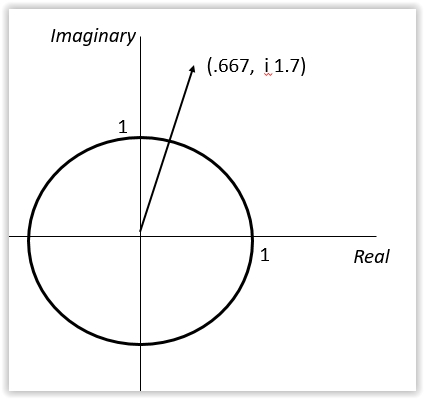

### Ex: Checking Causality 2

Check to see of AR(2) model,
$$Y_t = -.7 Y_{t-1} - .6Y_{t-2} + e_{t}$$
is causal or not.

We have to look at the root of
$$\Phi(z) = 1 + .7z + .6z^2,$$
which has roots $-.583 1.15 i $.

```r
  z = polyroot(c(1,.7,.6))   # find root of 1+.7z+.6z^2
  z                           #- see the root
```

```
## [1] -0.583333+1.15169i -0.583333-1.15169i
```

```r
  Mod(z)                      #- Distance from origin
```

```
## [1] 1.290994 1.290994
```

They are at at distance $\sqrt{(-.583)^2+(1.15i)^2} = 1.29$ from origin. Therefore, this AR(2) is causal.

### Ex: Checking Causality 3

Given
$$X_t = .7 X_{t-1} + .6 X_{t-2} + e_{t},$$
Check the causality.

we look at the root of
$$\Phi(z) = 1 - .7z - .6z^2,$$

```r
  z = polyroot(c(1,-.7,-.6))
  z
```

```
## [1]  0.8333333+0i -2.0000000+0i
```

```r
  Mod(z)
```

```
## [1] 0.8333333 2.0000000
```

## Summary

- AR($p$) is defined as
  $$X_t - \phi_1 X_{t-1} - \phi_2 X_{t-2} - \cdots - \phi_p X_{t-p}
  \hspace3mm = \hspace3mm \epsilon_t, \\
  (1 - \phi_1 B - \phi_2 B^2 - \cdots - \phi_p B^p) \, X_t
  \hspace3mm = \hspace3mm \epsilon_t. \\
  \Phi(B) \hspace2mm X_t \hspace3mm = \hspace3mm \epsilon_t.$$
  where $\phi_1, \ldots, \phi_p$ is real valued constant, and $\epsilon_t \sim WN(0,\sigma^2)$.
- AR($p$) can be written in causal representation,
  $$X_t = \sum_{i=0}^\infty \phi^{i} \, \epsilon_{t-i},$$
  when its characteristic polynomial $\Phi(z)$ has all the roots **outside** of the unit circle on the imaginary plane.

When the AR($p$) can be written as causal process, then it is stationary.

You can use **polyroot()** function in R to calculate the roots of polynomial, and **Mod()* to calculate their distance from the origin.

```r
  z = polyroot(c(1,.7,.6))   # find root of 1+.7z+.6z^2
  z                           # see the root
  Mod(z)                      # Distance from origin
```